# Clase 10. Aplicacion Forecast de ARIMA(p, d, q) y ARMA(p, q)

Series de Tiempo | Semestre 2027-I | FC-UNAM

Benjamin Oliva & Omar Alfaro-Rivera

julio 2026

## ¿Qué aprenderemos hoy?

**Datos:** `Base_Transporte_ARIMA.xlsx` — transporte aéreo INEGI con dummies para sismo 2017 y COVID-19

# Importamos Datos:

Los datos importados son:

- Pax_Nal: Pasajeros (Salidas) en vuelos nacionales
- Pax_Int: Pasajeros (Salidas) en vuelos internacionales
- Vue_Nal: Vuelos u operaciones (Salidas) en vuelos nacionales
- Vue_Int: Vuelos u operaciones (Salidas) en vuelos internacionales
- Pax_Metro: Pasajeros transportados (Millones) en el SCM
- D_Sep2017: Dummy que toma el valor de 1 en septiembre de 2017
- D_Oct2017: Dummy que toma el valor de 1 en octubre de 2017
- D_Feb2020: Dummy que toma el valor de 1 en febrero de 2020
- D_Mar2020: Dummy que toma el valor de 1 en marzo de 2020
- D_Abr2020: Dummy que toma el valor de 1 en abril de 2020
- D_May2020: Dummy que toma el valor de 1 en mayo de 2020
- D_Jun2020: Dummy que toma el valor de 1 en junio de 2020
- D_Jul2020: Dummy que toma el valor de 1 en julio de 2020
- D_Ene2021: Dummy que toma el valor de 1 en enero de 2021
- D_Mar2021: Dummy que toma el valor de 1 en marzo de 2021
- D_Ene: Dummy que toma el valor de 1 en todos los eneros
- D_Dic: Dummy que toma el valor de 1 en todos los diciembres

Fuente: INEGI, https://www.inegi.org.mx/app/indicadores/?tm=0&t=1090

```r
Datos <- read_excel("../data/Base_Transporte_ARIMA.xlsx", sheet = "Datos", col_names = TRUE)

tail(Datos)
```

```
## # A tibble: 6 × 22
##   Periodo             Pax_Nal Pax_Int Vue_Nal Vue_Int Pax_Metro D_Sep2017
##   <dttm>                <dbl>   <dbl>   <dbl>   <dbl>     <dbl>     <dbl>
## 1 2025-01-01 00:00:00 4945636 2520804   35349   19081      96.6         0
## 2 2025-02-01 00:00:00 4370469 2414260   31316   17136      94.3         0
## 3 2025-03-01 00:00:00 5099762 2784001   35266   20198     105.          0
## 4 2025-04-01 00:00:00 5311786 2415110   36558   18077      97.6         0
## 5 2025-05-01 00:00:00 5212654 2222848   36531   16127     104.          0
## 6 2025-06-01 00:00:00 5025360 2396012   35141   16367     100.          0
## # ℹ 15 more variables: D_Oct2017 <dbl>, D_Feb2020 <dbl>, D_Mar2020 <dbl>,
## #   D_Abr2020 <dbl>, D_May2020 <dbl>, D_Jun2020 <dbl>, D_Jul2020 <dbl>,
## #   D_Ene2021 <dbl>, D_Mar2021 <dbl>, D_Ene <dbl>, D_Feb <dbl>, D_Jul <dbl>,
## #   D_Dic <dbl>, D_Ene2022 <dbl>, D_Feb2022 <dbl>
```

# Conversion a series de tiempo:

```r
Pax_Nal <- ts(Datos$Pax_Nal,
              start = c(2000, 1),
              freq = 12)

LPax_Nal <- ts(log(Datos$Pax_Nal),
               start = c(2000, 1),
               freq = 12)

DLPax_Nal <- ts(log(Datos$Pax_Nal) - lag(log(Datos$Pax_Nal), 1),
                start = c(2000, 1),
                freq = 12)

D_Mar2020   <- ts(Datos$D_Mar2020,
                start = c(2000, 1),
                freq = 12)

D_Abr2020   <- ts(Datos$D_Abr2020,
                start = c(2000, 1),
                freq = 12)

D_Jun2020   <- ts(Datos$D_Jun2020,
                start = c(2000, 1),
                freq = 12)

D_Jul2020 <- ts(Datos$D_Jul2020,
                start = c(2000, 1),
                freq = 12)

D_Mar2021 <- ts(Datos$D_Mar2021,
                start = c(2000, 1),
                freq = 12)

D_Ene <- ts(Datos$D_Ene,
            start = c(2000, 1),
            freq = 12)

D_Feb <- ts(Datos$D_Feb,
            start = c(2000, 1),
            freq = 12)

D_Jul <- ts(Datos$D_Jul,
            start = c(2000, 1),
            freq = 12)

D_Dic <- ts(Datos$D_Dic,
            start = c(2000, 1),
            freq = 12)
```

# Graficas:

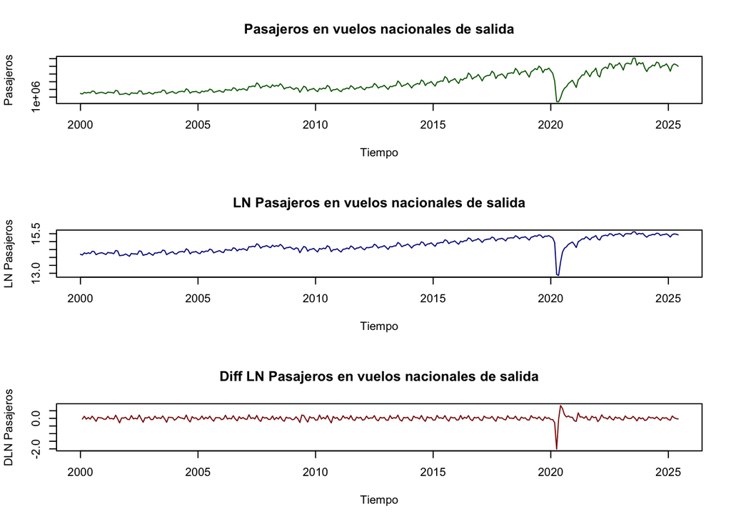

# Estimacion del proceso ARIMA(p, 1, q):

```r
ARMA_Ex_DLPax_Nal_2 <- arima(DLPax_Nal, order = c(6, 0, 6),
                             xreg = cbind(D_Ene, D_Feb, D_Jul, D_Dic, D_Mar2020, D_Abr2020, D_Jun2020, D_Jul2020, D_Mar2021),
                             method = "ML")
ARMA_Ex_DLPax_Nal_2
```

```
##
## Call:
## arima(x = DLPax_Nal, order = c(6, 0, 6), xreg = cbind(D_Ene, D_Feb, D_Jul, D_Dic,
##     D_Mar2020, D_Abr2020, D_Jun2020, D_Jul2020, D_Mar2021), method = "ML")
##
## Coefficients:
##          ar1      ar2     ar3      ar4     ar5      ar6      ma1      ma2
##       0.0014  -0.0015  0.0026  -0.0019  0.0028  -0.9973  -0.0048  -0.0455
## s.e.  0.0054   0.0033  0.0059   0.0035  0.0054   0.0021   0.0368   0.0275
##           ma3      ma4      ma5     ma6  intercept    D_Ene    D_Feb   D_Jul
##       -0.0851  -0.0020  -0.0541  0.9329     0.0187  -0.1497  -0.1685  0.1776
## s.e.   0.0390   0.0265   0.0342  0.0267     0.0037   0.0926   0.0155  0.0920
##         D_Dic  D_Mar2020  D_Abr2020  D_Jun2020  D_Jul2020  D_Mar2021
##       -0.0012    -0.4638    -1.9908     0.8939     0.5002     0.1814
## s.e.   0.0157     0.0498     0.0482     0.0493     0.0507     0.0487
##
## sigma^2 estimated as 0.002297:  log likelihood = 483.77,  aic = -921.55
```

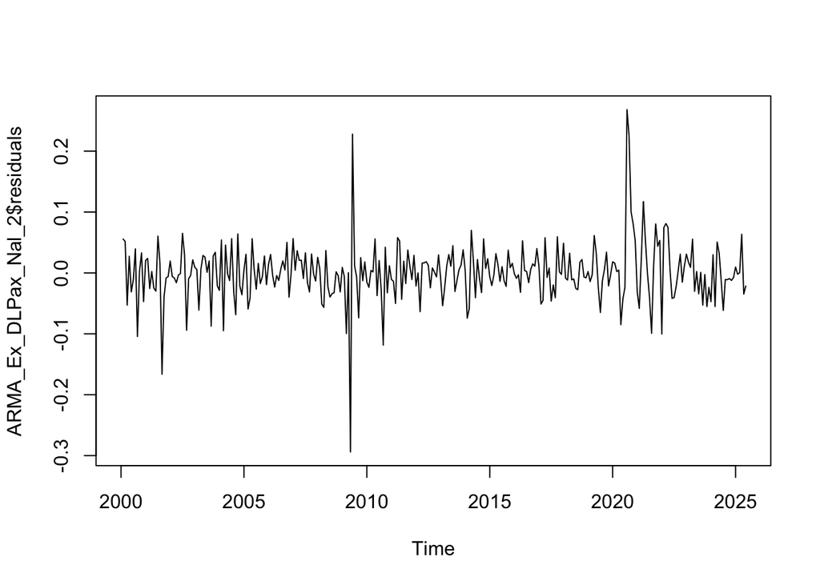

```r
plot(ARMA_Ex_DLPax_Nal_2$residuals)
```

# Forecast:

Datos Exogenos:

```r
Predict_Datos <- read_excel("Predict_Base_Transporte_ARIMA.xlsx", sheet = "Datos", col_names = TRUE)

head(Predict_Datos)
```

```
## # A tibble: 6 × 17
##   Periodo             D_Sep2017 D_Oct2017 D_Feb2020 D_Mar2020 D_Abr2020
##   <dttm>                  <dbl>     <dbl>     <dbl>     <dbl>     <dbl>
## 1 2025-07-01 00:00:00         0         0         0         0         0
## 2 2025-08-01 00:00:00         0         0         0         0         0
## 3 2025-09-01 00:00:00         0         0         0         0         0
## 4 2025-10-01 00:00:00         0         0         0         0         0
## 5 2025-11-01 00:00:00         0         0         0         0         0
## 6 2025-12-01 00:00:00         0         0         0         0         0
## # ℹ 11 more variables: D_May2020 <dbl>, D_Jun2020 <dbl>, D_Jul2020 <dbl>,
## #   D_Ene2021 <dbl>, D_Mar2021 <dbl>, D_Ene <dbl>, D_Feb <dbl>, D_Jul <dbl>,
## #   D_Dic <dbl>, D_Ene2022 <dbl>, D_Feb2022 <dbl>
```

# Conversion a series de tiempo:

```r
D_Mar2020_f <- ts(Predict_Datos$D_Mar2020,
                start = c(2025, 7),
                freq = 12)

D_Abr2020_f <- ts(Predict_Datos$D_Abr2020,
                start = c(2025, 7),
                freq = 12)

D_Jun2020_f <- ts(Predict_Datos$D_Jun2020,
                start = c(2025, 7),
                freq = 12)

D_Jul2020_f <- ts(Predict_Datos$D_Jul2020,
                start = c(2025, 7),
                freq = 12)

D_Mar2021_f <- ts(Predict_Datos$D_Mar2021,
                start = c(2025, 7),
                freq = 12)

D_Ene_f <- ts(Predict_Datos$D_Ene,
            start = c(2025, 7),
            freq = 12)

D_Feb_f <- ts(Predict_Datos$D_Feb,
            start = c(2025, 7),
            freq = 12)

D_Jul_f <- ts(Predict_Datos$D_Jul,
           start = c(2025, 7),
            freq = 12)

D_Dic_f <- ts(Predict_Datos$D_Dic,
            start = c(2025, 7),
            freq = 12)
```